# (Flights Data Exploration)

## by (Mohammed Alabdullatif)

## Preliminary Wrangling

> This dataset reports flights in the United States, including carriers, arrival and departure delays, and reasons for delays, for 1988, 1998 and 2008

```python
# import all packages and set plots to be embedded inline
import numpy as np
import pandas as pd
import matplotlib.pyplot as plt
import seaborn as sb

%matplotlib inline
```

```python
# import in data for flights for 1988 into pandas
flights_1988 = pd.read_csv('1988.csv')
# import in data for flights for 1998 into pandas
flights_1998 = pd.read_csv('1998.csv')
# import in data for flights for 2008 into pandas
flights_2008 = pd.read_csv('2008.csv')
```

```python
# high-level overview of data shape and composition for 1988
print(flights_1988.shape)
print(flights_1988.dtypes)
print(flights_1988.head(10))
```

```
(5202096, 29)
Year                   int64
Month                  int64
DayofMonth             int64
DayOfWeek              int64
DepTime              float64
CRSDepTime             int64
ArrTime              float64
CRSArrTime             int64
UniqueCarrier         object
FlightNum              int64
TailNum              float64
ActualElapsedTime    float64
CRSElapsedTime         int64
AirTime              float64
ArrDelay             float64
DepDelay             float64
Origin                object
Dest                  object
Distance             float64
TaxiIn               float64
TaxiOut              float64
Cancelled              int64
CancellationCode     float64
Diverted               int64
CarrierDelay         float64
WeatherDelay         float64
NASDelay             float64
SecurityDelay        float64
LateAircraftDelay    float64
dtype: object
   Year  Month  DayofMonth  DayOfWeek  DepTime  CRSDepTime  ArrTime  \
0  1988      1           9          6   1348.0        1331   1458.0
1  1988      1          10          7   1334.0        1331   1443.0
2  1988      1          11          1   1446.0        1331   1553.0
3  1988      1          12          2   1334.0        1331   1438.0
4  1988      1          13          3   1341.0        1331   1503.0
5  1988      1          14          4   1332.0        1331   1447.0
6  1988      1          15          5   1331.0        1331   1434.0
7  1988      1          16          6   1327.0        1331   1427.0
```

[output cut: 25 more lines]

```
9               NaN         0           NaN          NaN      NaN

   SecurityDelay  LateAircraftDelay
0            NaN                NaN
1            NaN                NaN
2            NaN                NaN
3            NaN                NaN
4            NaN                NaN
5            NaN                NaN
6            NaN                NaN
7            NaN                NaN
8            NaN                NaN
9            NaN                NaN

[10 rows x 29 columns]
```

```python
# high-level overview of data shape and composition for 1998
print(flights_1998.shape)
print(flights_1998.dtypes)
print(flights_1998.head(10))
```

```
(5384721, 29)
Year                   int64
Month                  int64
DayofMonth             int64
DayOfWeek              int64
DepTime              float64
CRSDepTime             int64
ArrTime              float64
CRSArrTime             int64
UniqueCarrier         object
FlightNum              int64
TailNum               object
ActualElapsedTime    float64
CRSElapsedTime       float64
AirTime              float64
ArrDelay             float64
DepDelay             float64
Origin                object
Dest                  object
Distance               int64
TaxiIn                 int64
TaxiOut                int64
Cancelled              int64
CancellationCode     float64
Diverted               int64
CarrierDelay         float64
WeatherDelay         float64
NASDelay             float64
SecurityDelay        float64
LateAircraftDelay    float64
dtype: object
   Year  Month  DayofMonth  DayOfWeek  DepTime  CRSDepTime  ArrTime  \
0  1998      1          17          6    715.0         715    840.0
1  1998      1          18          7    715.0         715    830.0
2  1998      1          19          1    715.0         715    831.0
3  1998      1          20          2    715.0         715    836.0
4  1998      1          21          3    715.0         715    836.0
5  1998      1          22          4    725.0         715    847.0
6  1998      1          23          5    715.0         715    839.0
7  1998      1          24          6    715.0         715    830.0
```

[output cut: 25 more lines]

```
9               NaN         0           NaN          NaN      NaN

   SecurityDelay  LateAircraftDelay
0            NaN                NaN
1            NaN                NaN
2            NaN                NaN
3            NaN                NaN
4            NaN                NaN
5            NaN                NaN
6            NaN                NaN
7            NaN                NaN
8            NaN                NaN
9            NaN                NaN

[10 rows x 29 columns]
```

```python
# high-level overview of data shape and composition for 2008
print(flights_2008.shape)
print(flights_2008.dtypes)
print(flights_2008.head(10))
```

```
(7009728, 29)
Year                   int64
Month                  int64
DayofMonth             int64
DayOfWeek              int64
DepTime              float64
CRSDepTime             int64
ArrTime              float64
CRSArrTime             int64
UniqueCarrier         object
FlightNum              int64
TailNum               object
ActualElapsedTime    float64
CRSElapsedTime       float64
AirTime              float64
ArrDelay             float64
DepDelay             float64
Origin                object
Dest                  object
Distance               int64
TaxiIn               float64
TaxiOut              float64
Cancelled              int64
CancellationCode      object
Diverted               int64
CarrierDelay         float64
WeatherDelay         float64
NASDelay             float64
SecurityDelay        float64
LateAircraftDelay    float64
dtype: object
   Year  Month  DayofMonth  DayOfWeek  DepTime  CRSDepTime  ArrTime  \
0  2008      1           3          4   2003.0        1955   2211.0
1  2008      1           3          4    754.0         735   1002.0
2  2008      1           3          4    628.0         620    804.0
3  2008      1           3          4    926.0         930   1054.0
4  2008      1           3          4   1829.0        1755   1959.0
5  2008      1           3          4   1940.0        1915   2121.0
6  2008      1           3          4   1937.0        1830   2037.0
7  2008      1           3          4   1039.0        1040   1132.0
```

[output cut: 25 more lines]

```
9               NaN         0           NaN          NaN      NaN

   SecurityDelay  LateAircraftDelay
0            NaN                NaN
1            NaN                NaN
2            NaN                NaN
3            NaN                NaN
4            0.0               32.0
5            NaN                NaN
6            0.0               47.0
7            NaN                NaN
8            NaN                NaN
9            NaN                NaN

[10 rows x 29 columns]
```

```python
flights_2008.isnull().sum()
```

```
Year                       0
Month                      0
DayofMonth                 0
DayOfWeek                  0
DepTime               136246
CRSDepTime                 0
ArrTime               151649
CRSArrTime                 0
UniqueCarrier              0
FlightNum                  0
TailNum                83365
ActualElapsedTime     154699
CRSElapsedTime           844
AirTime               154699
ArrDelay              154699
DepDelay              136246
Origin                     0
Dest                       0
Distance                   0
TaxiIn                151649
TaxiOut               137058
Cancelled                  0
CancellationCode     6872294
Diverted                   0
CarrierDelay         5484993
WeatherDelay         5484993
NASDelay             5484993
SecurityDelay        5484993
LateAircraftDelay    5484993
dtype: int64
```

```python
# marge the 3 years data into one Datafarme, since all the data strucure are the same
flights = pd.concat([flights_1988, flights_1998, flights_2008])
```

```python
# high-level overview of data shape and composition for 2008
print(flights.shape)
print(flights.dtypes)
print(flights.head(10))
```

```
(17596545, 29)
Year                   int64
Month                  int64
DayofMonth             int64
DayOfWeek              int64
DepTime              float64
CRSDepTime             int64
ArrTime              float64
CRSArrTime             int64
UniqueCarrier         object
FlightNum              int64
TailNum               object
ActualElapsedTime    float64
CRSElapsedTime       float64
AirTime              float64
ArrDelay             float64
DepDelay             float64
Origin                object
Dest                  object
Distance             float64
TaxiIn               float64
TaxiOut              float64
Cancelled              int64
CancellationCode      object
Diverted               int64
CarrierDelay         float64
WeatherDelay         float64
NASDelay             float64
SecurityDelay        float64
LateAircraftDelay    float64
dtype: object
   Year  Month  DayofMonth  DayOfWeek  DepTime  CRSDepTime  ArrTime  \
0  1988      1           9          6   1348.0        1331   1458.0
1  1988      1          10          7   1334.0        1331   1443.0
2  1988      1          11          1   1446.0        1331   1553.0
3  1988      1          12          2   1334.0        1331   1438.0
4  1988      1          13          3   1341.0        1331   1503.0
5  1988      1          14          4   1332.0        1331   1447.0
6  1988      1          15          5   1331.0        1331   1434.0
7  1988      1          16          6   1327.0        1331   1427.0
```

[output cut: 25 more lines]

```
9               NaN         0           NaN          NaN      NaN

   SecurityDelay  LateAircraftDelay
0            NaN                NaN
1            NaN                NaN
2            NaN                NaN
3            NaN                NaN
4            NaN                NaN
5            NaN                NaN
6            NaN                NaN
7            NaN                NaN
8            NaN                NaN
9            NaN                NaN

[10 rows x 29 columns]
```

```python
pd.set_option('display.max_columns', None)
flights.head(20)
```

|  | Year | Month | DayofMonth | DayOfWeek | DepTime | CRSDepTime | ArrTime | CRSArrTime | UniqueCarrier | FlightNum | TailNum | ActualElapsedTime | CRSElapsedTime | AirTime | ArrDelay | DepDelay | Origin | Dest | Distance | TaxiIn | TaxiOut | Cancelled | CancellationCode | Diverted | CarrierDelay | WeatherDelay | NASDelay | SecurityDelay | LateAircraftDelay |
| --- | --- | --- | --- | --- | --- | --- | --- | --- | --- | --- | --- | --- | --- | --- | --- | --- | --- | --- | --- | --- | --- | --- | --- | --- | --- | --- | --- | --- | --- |
| 0 | 1988 | 1 | 9 | 6 | 1348.0 | 1331 | 1458.0 | 1435 | PI | 942 | NaN | 70.0 | 64.0 | NaN | 23.0 | 17.0 | SYR | BWI | 273.0 | NaN | NaN | 0 | NaN | 0 | NaN | NaN | NaN | NaN | NaN |
| 1 | 1988 | 1 | 10 | 7 | 1334.0 | 1331 | 1443.0 | 1435 | PI | 942 | NaN | 69.0 | 64.0 | NaN | 8.0 | 3.0 | SYR | BWI | 273.0 | NaN | NaN | 0 | NaN | 0 | NaN | NaN | NaN | NaN | NaN |
| 2 | 1988 | 1 | 11 | 1 | 1446.0 | 1331 | 1553.0 | 1435 | PI | 942 | NaN | 67.0 | 64.0 | NaN | 78.0 | 75.0 | SYR | BWI | 273.0 | NaN | NaN | 0 | NaN | 0 | NaN | NaN | NaN | NaN | NaN |
| 3 | 1988 | 1 | 12 | 2 | 1334.0 | 1331 | 1438.0 | 1435 | PI | 942 | NaN | 64.0 | 64.0 | NaN | 3.0 | 3.0 | SYR | BWI | 273.0 | NaN | NaN | 0 | NaN | 0 | NaN | NaN | NaN | NaN | NaN |
| 4 | 1988 | 1 | 13 | 3 | 1341.0 | 1331 | 1503.0 | 1435 | PI | 942 | NaN | 82.0 | 64.0 | NaN | 28.0 | 10.0 | SYR | BWI | 273.0 | NaN | NaN | 0 | NaN | 0 | NaN | NaN | NaN | NaN | NaN |
| 5 | 1988 | 1 | 14 | 4 | 1332.0 | 1331 | 1447.0 | 1435 | PI | 942 | NaN | 75.0 | 64.0 | NaN | 12.0 | 1.0 | SYR | BWI | 273.0 | NaN | NaN | 0 | NaN | 0 | NaN | NaN | NaN | NaN | NaN |
| 6 | 1988 | 1 | 15 | 5 | 1331.0 | 1331 | 1434.0 | 1435 | PI | 942 | NaN | 63.0 | 64.0 | NaN | -1.0 | 0.0 | SYR | BWI | 273.0 | NaN | NaN | 0 | NaN | 0 | NaN | NaN | NaN | NaN | NaN |
| 7 | 1988 | 1 | 16 | 6 | 1327.0 | 1331 | 1427.0 | 1435 | PI | 942 | NaN | 60.0 | 64.0 | NaN | -8.0 | -4.0 | SYR | BWI | 273.0 | NaN | NaN | 0 | NaN | 0 | NaN | NaN | NaN | NaN | NaN |
| 8 | 1988 | 1 | 17 | 7 | 1331.0 | 1331 | 1440.0 | 1435 | PI | 942 | NaN | 69.0 | 64.0 | NaN | 5.0 | 0.0 | SYR | BWI | 273.0 | NaN | NaN | 0 | NaN | 0 | NaN | NaN | NaN | NaN | NaN |
| 9 | 1988 | 1 | 18 | 1 | 1349.0 | 1331 | 1519.0 | 1435 | PI | 942 | NaN | 90.0 | 64.0 | NaN | 44.0 | 18.0 | SYR | BWI | 273.0 | NaN | NaN | 0 | NaN | 0 | NaN | NaN | NaN | NaN | NaN |
| 10 | 1988 | 1 | 19 | 2 | 1337.0 | 1331 | 1438.0 | 1435 | PI | 942 | NaN | 61.0 | 64.0 | NaN | 3.0 | 6.0 | SYR | BWI | 273.0 | NaN | NaN | 0 | NaN | 0 | NaN | NaN | NaN | NaN | NaN |
| 11 | 1988 | 1 | 20 | 3 | 1337.0 | 1331 | 1452.0 | 1435 | PI | 942 | NaN | 75.0 | 64.0 | NaN | 17.0 | 6.0 | SYR | BWI | 273.0 | NaN | NaN | 0 | NaN | 0 | NaN | NaN | NaN | NaN | NaN |
| 12 | 1988 | 1 | 21 | 4 | 1330.0 | 1331 | 1459.0 | 1435 | PI | 942 | NaN | 89.0 | 64.0 | NaN | 24.0 | -1.0 | SYR | BWI | 273.0 | NaN | NaN | 0 | NaN | 0 | NaN | NaN | NaN | NaN | NaN |
| 13 | 1988 | 1 | 22 | 5 | 1331.0 | 1331 | 1434.0 | 1435 | PI | 942 | NaN | 63.0 | 64.0 | NaN | -1.0 | 0.0 | SYR | BWI | 273.0 | NaN | NaN | 0 | NaN | 0 | NaN | NaN | NaN | NaN | NaN |
| 14 | 1988 | 1 | 23 | 6 | 1333.0 | 1331 | 1436.0 | 1435 | PI | 942 | NaN | 63.0 | 64.0 | NaN | 1.0 | 2.0 | SYR | BWI | 273.0 | NaN | NaN | 0 | NaN | 0 | NaN | NaN | NaN | NaN | NaN |
| 15 | 1988 | 1 | 24 | 7 | 1328.0 | 1331 | 1430.0 | 1435 | PI | 942 | NaN | 62.0 | 64.0 | NaN | -5.0 | -3.0 | SYR | BWI | 273.0 | NaN | NaN | 0 | NaN | 0 | NaN | NaN | NaN | NaN | NaN |
| 16 | 1988 | 1 | 25 | 1 | 1330.0 | 1331 | 1444.0 | 1435 | PI | 942 | NaN | 74.0 | 64.0 | NaN | 9.0 | -1.0 | SYR | BWI | 273.0 | NaN | NaN | 0 | NaN | 0 | NaN | NaN | NaN | NaN | NaN |
| 17 | 1988 | 1 | 26 | 2 | 1407.0 | 1331 | 1518.0 | 1435 | PI | 942 | NaN | 71.0 | 64.0 | NaN | 43.0 | 36.0 | SYR | BWI | 273.0 | NaN | NaN | 0 | NaN | 0 | NaN | NaN | NaN | NaN | NaN |
| 18 | 1988 | 1 | 27 | 3 | 1332.0 | 1331 | 1445.0 | 1435 | PI | 942 | NaN | 73.0 | 64.0 | NaN | 10.0 | 1.0 | SYR | BWI | 273.0 | NaN | NaN | 0 | NaN | 0 | NaN | NaN | NaN | NaN | NaN |
| 19 | 1988 | 1 | 28 | 4 | 1331.0 | 1331 | 1438.0 | 1435 | PI | 942 | NaN | 67.0 | 64.0 | NaN | 3.0 | 0.0 | SYR | BWI | 273.0 | NaN | NaN | 0 | NaN | 0 | NaN | NaN | NaN | NaN | NaN |

### What is the structure of your dataset?

> There are 17,596,545 flights in the dataset with 29 columns:
> - **Year**: 1988,1998, 2008
> - **Month**: 1-12
> - **DayofMonth**: 1-31
> - **DayOfWeek**: 1 (Monday) - 7 (Sunday)
> - **DepTime**: actual departure time (local, hhmm)
> - **CRSDepTime**: scheduled departure time (local, hhmm)
> - **ArrTime**: actual arrival time (local, hhmm)
> - **CRSArrTime**: scheduled arrival time (local, hhmm)
> - **UniqueCarrier**: unique carrier code
> - **FlightNum**: flight number
> - **TailNum**: plane tail number
> - **ActualElapsedTime**: in minutes
> - **CRSElapsedTime**: in minutes
> - **AirTime**: in minutes
> - **ArrDelay**: arrival delay, in minutes
> - **DepDelay**: departure delay, in minutes
> - **Origin**: origin IATA airport code
> - **Dest**: destination IATA airport code
> - **Distance**: in miles
> - **TaxiIn**: taxi in time, in minutes
> - **TaxiOut**: taxi out time in minutes
> - **Cancelled**: was the flight cancelled? (1 = yes, 0 = no)
> - **CancellationCode**: reason for cancellation (A = carrier, B = weather, C = NAS, D = security)
> - **Diverted**: 1 = yes, 0 = no
> - **CarrierDelay**: in minutes
> - **WeatherDelay**: in minutes
> - **NASDelay**: in minutes
> - **SecurityDelay**: in minutes
> - **LateAircraftDelay**: in minutes

### What is/are the main feature(s) of interest in your dataset?

> I'm Intrested to know more about the flights delays and the cancelation and is the airport effect.

### What features in the dataset do you think will help support your investigation into your feature(s) of interest?

> I expect that Delay code will lead us to the reason for the delay.

## Univariate Exploration

> In this section, investigate distributions of individual variables

```python
# create a new columns for Status to show the status of the flight

# since the arraive delay less than 15m so we consider it on time
flights.loc[flights['ArrDelay'] <= 15 , 'Status'] = 0

# if it's more than 15m we will consider it as delayed
flights.loc[flights['ArrDelay'] > 15 , 'Status'] = 1

# if the flight is Diverted
flights.loc[flights['Diverted'] == 1 , 'Status'] = 2

# if the flight cancelled
flights.loc[flights['Cancelled'] == 1 , 'Status'] = 3
```

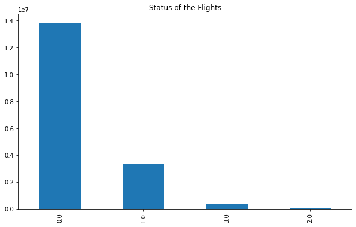

```python
plt.title('Status of the Flights') # add the title
flights['Status'].value_counts().plot(kind="bar", figsize=[10,6]); # plot the digram in bar type and change it the size
```

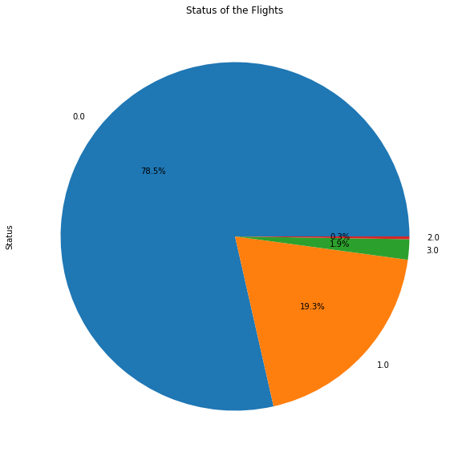

```python
plt.title('Status of the Flights') #add the title
# plot the digram in pie type, write the persintage on the pie and change it the size
flights['Status'].value_counts().plot(kind="pie",autopct='%1.1f%%', figsize=[12,10]);
```

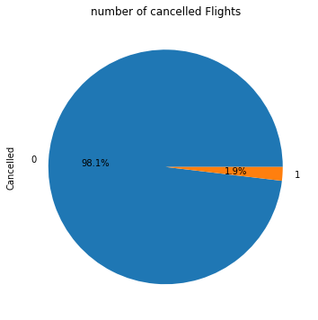

```python
plt.title('number of cancelled Flights') #add the title
# plot the digram in pie type, write the persintage on the pie and change it the size
flights['Cancelled'].value_counts().plot(kind="pie",autopct='%1.1f%%', figsize=[10,6]);
```

what we can see from the plot of cancelled flight is most of the Flights fly even if there's any delay.

```python
# Get the top 10 of origin Airports
top_10_Origin = flights.Origin.value_counts().head(10) # create a value to count the total number of the arri
top_10_Origin_list = flights.Origin.value_counts().head(10).keys().tolist() #store the airport in list
```

```python
top_10_Origin
```

```
ATL    929624
ORD    916770
DFW    742143
LAX    569382
DEN    538938
PHX    491853
DTW    423516
SFO    412054
IAH    395306
EWR    384052
Name: Origin, dtype: int64
```

```python
top_10_Origin_list
```

```
['ATL', 'ORD', 'DFW', 'LAX', 'DEN', 'PHX', 'DTW', 'SFO', 'IAH', 'EWR']
```

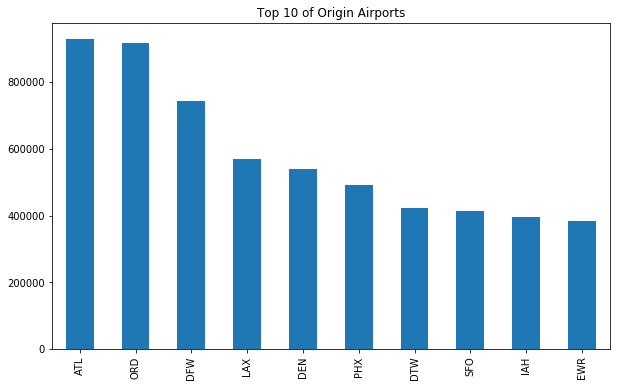

```python
plt.title('Top 10 of Origin Airports') #add the title
top_10_Origin.plot(kind="bar", figsize=[10,6]); # plot the digram in bar type and change it the size
```

The top 10 Airports for the flights

```python
# Get the top 10 of Dep Airports
top_10_Dep = flights.Dest.value_counts().head(10) # create a value to count the total number of the dep
top_10_Dep_list = flights.Dest.value_counts().head(10).keys().tolist() #store the airport in list
```

```python
top_10_Dep
```

```
ATL    930381
ORD    920128
DFW    745716
LAX    569513
DEN    541430
PHX    492906
DTW    427150
SFO    410505
IAH    396969
EWR    384916
Name: Dest, dtype: int64
```

```python
top_10_Dep_list
```

```
['ATL', 'ORD', 'DFW', 'LAX', 'DEN', 'PHX', 'DTW', 'SFO', 'IAH', 'EWR']
```

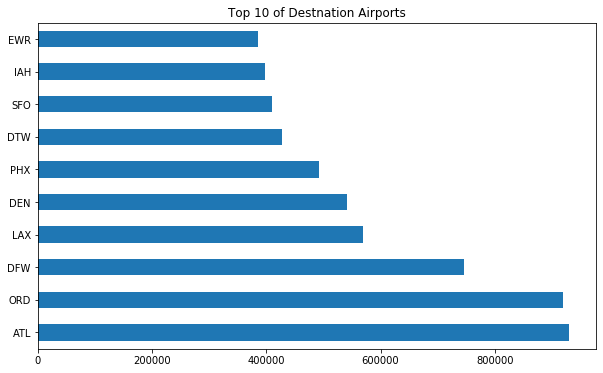

```python
plt.title('Top 10 of Destnation Airports') #add the title
top_10_Dep.plot(kind="barh", figsize=[10,6]); # plot the digram in bar type and change it the size
```

Top 10 Destnation Airports

### Discuss the distribution(s) of your variable(s) of interest. Were there any unusual points? Did you need to perform any transformations?

> 1- Status Variable: created this variable to store the status for each flight, and which status is higher, ( on time, delayed, Diverted or Canceled) 2- top_10_Origin created a filitered variable so i can visulasation it for the most trafic Origin Airports. 3- top_10_Dep created a filitered variable so i can visulasation it for the most trafic destination Airports.

### Of the features you investigated, were there any unusual distributions? Did you perform any operations on the data to tidy, adjust, or change the form of the data? If so, why did you do this?

> yes i had to create a new variable called status to reduce the operations and can do investigation faster

## Bivariate Exploration

> I'm looking for most Airports have cancelaction and delay.

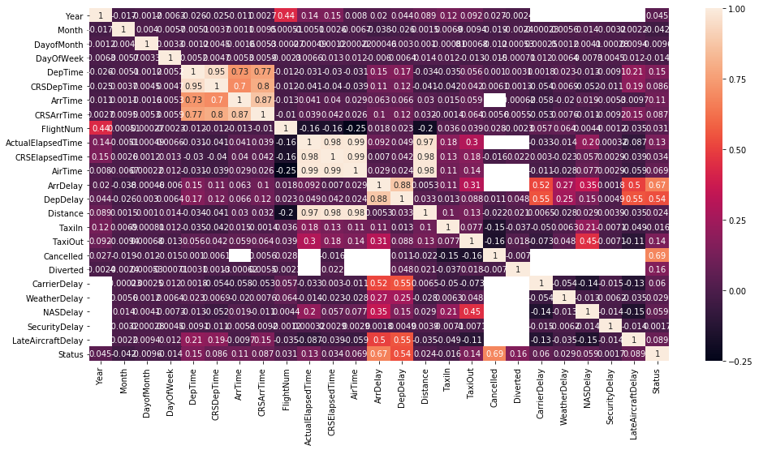

```python
# draw heat map to see relation with the columns
corrMatrix = flights.corr()
plt.figure(figsize = (16,8))
sb.heatmap(corrMatrix, annot=True);
```

```python
Flights_Top_Arr = flights.query('Origin in @top_10_Origin_list') # use a query to create a list for arrive flights in the top 10 lists
```

```python
Flights_Top_Dep = flights.query('Origin in @top_10_Dep_list') # use a query to create a list for Dep flights in the top 10 lists
```

```python
Flights_Top_Arr_Delay = Flights_Top_Arr.query('Status == 1') #create a dataset where's the flight is delay in the top Arrive ariports
Flights_Top_Dep_Delay = Flights_Top_Dep.query('Status == 1') #create a dataset where's the flight is delay in the top Dep ariports
```

```python
Flights_Top_Arr_Can = Flights_Top_Arr.query('Status == 3') #create a dataset where's the flight is cancelled in the top Arrive ariports
Flights_Top_Dep_Can = Flights_Top_Dep.query('Status == 3') #create a dataset where's the flight is cancelled in the top Dep ariports
```

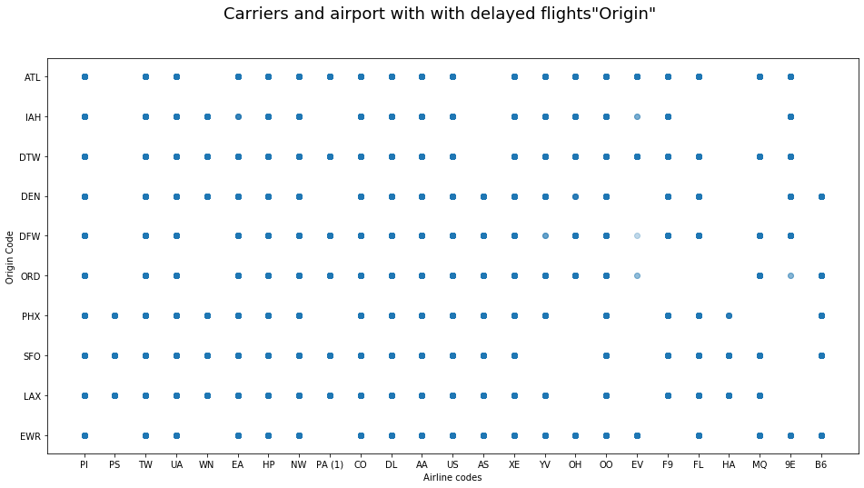

```python
# write the plot size
fig = plt.figure(figsize = [16,8])

# use the scatter
plt.scatter(data = Flights_Top_Arr_Delay, x = 'UniqueCarrier', y='Origin', alpha = .1)

# write the title
fig.suptitle('Carriers and airport with with delayed flights"Origin"', fontsize=18)

# write x and y labels
plt.xlabel('Airline codes')
plt.ylabel('Origin Code');
```

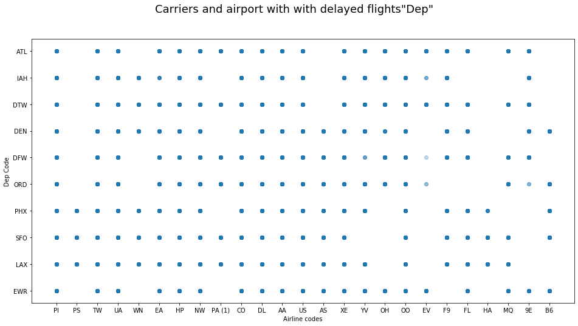

```python
# write the plot size
fig = plt.figure(figsize = [16,8])

# use the scatter
plt.scatter(data = Flights_Top_Dep_Delay, x = 'UniqueCarrier', y='Origin', alpha = .1)

# write the title
fig.suptitle('Carriers and airport with with delayed flights"Dep"', fontsize=18)

# write x and y labels
plt.xlabel('Airline codes')
plt.ylabel('Dep Code');
```

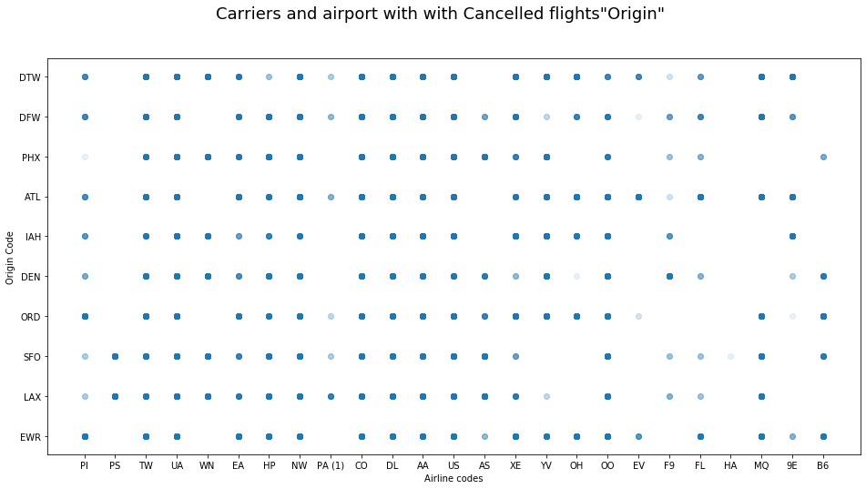

```python
# Set the plot size
fig = plt.figure(figsize = [16,8])

# use the scatter
plt.scatter(data = Flights_Top_Arr_Can, x = 'UniqueCarrier', y='Origin', alpha = .1)

# write the title
fig.suptitle('Carriers and airport with with Cancelled flights"Origin"', fontsize=18)

# write x and y labels
plt.xlabel('Airline codes')
plt.ylabel('Origin Code');
```

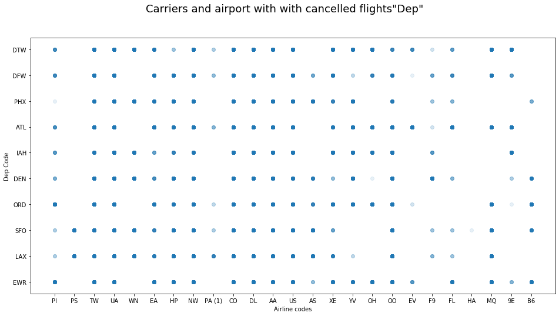

```python
# Set the plot size
fig = plt.figure(figsize = [16,8])

# use the scatter
plt.scatter(data = Flights_Top_Dep_Can, x = 'UniqueCarrier', y='Origin', alpha = .1)

# write the title
fig.suptitle('Carriers and airport with with cancelled flights"Dep"', fontsize=18)

# write x and y labels
plt.xlabel('Airline codes')
plt.ylabel('Dep Code');
```

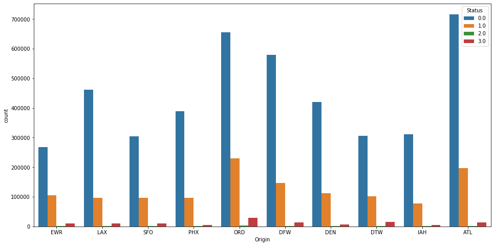

```python
# Set the plot size
fig = plt.figure(figsize = [16,8])

# use the bar plot
sb.countplot(data = Flights_Top_Arr, x = 'Origin', hue = 'Status');
```

ORD and ATl have the most Delay Airports.

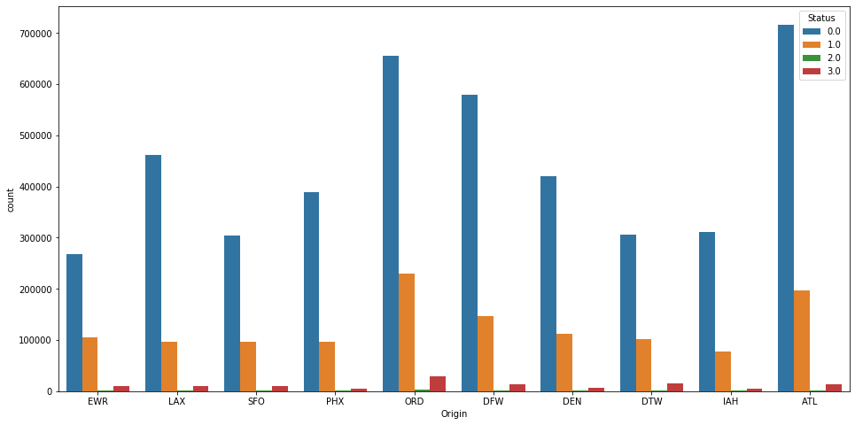

```python
# Set the plot size
fig = plt.figure(figsize = [16,8])

# use the bar plot
sb.countplot(data = Flights_Top_Dep, x = 'Origin', hue = 'Status');
```

ORD and ATl have the most Delay Airports.

IAH is the less Airport with Delay

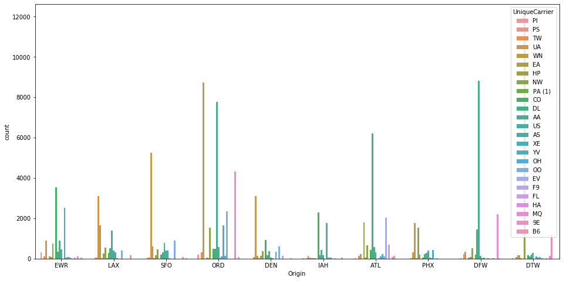

```python
# Set the plot size
fig = plt.figure(figsize = [16,8])

# use the bar plot
sb.countplot(data = Flights_Top_Dep_Can, x = 'Origin', hue = 'UniqueCarrier');
```

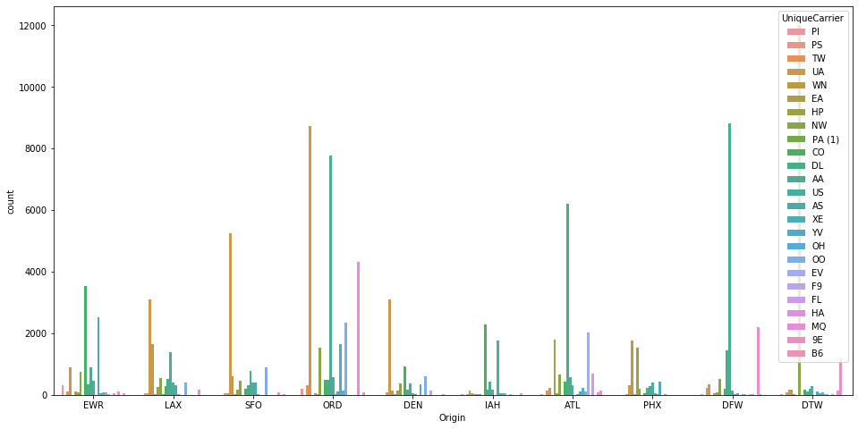

```python
# Set the plot size
fig = plt.figure(figsize = [16,8])

# use the bar plot
sb.countplot(data = Flights_Top_Arr_Can, x = 'Origin', hue = 'UniqueCarrier');
```

### Did you observe any interesting relationships between the other features (not the main feature(s) of interest)?

> Yes between the Airports and Airlines for both the delay and cancellation is the same.

## Multivariate Exploration

> Create plots of three or more variables to investigate your data even further.

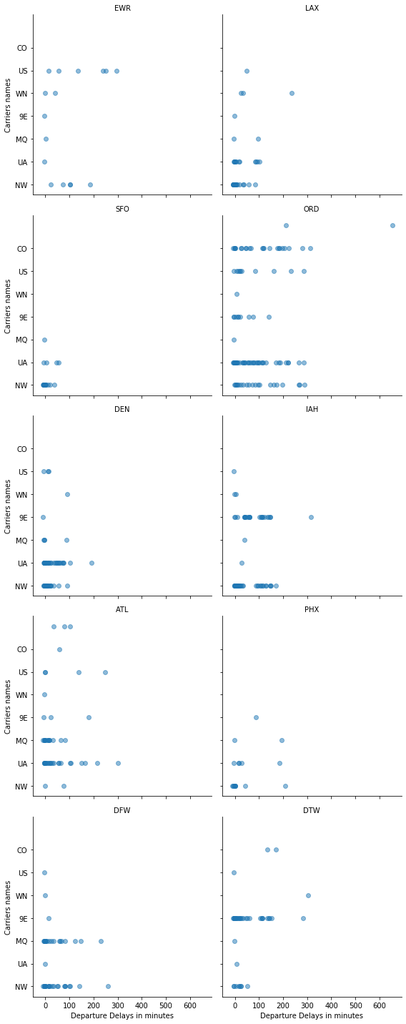

```python
# plot 3 variables : carrier (Carrier, departure delay and Origin

# I use faceting by Origin
Flight_Cancel_plot = sb.FacetGrid(Flights_Top_Arr_Can, col = 'Origin', col_wrap = 2,palette="Set1", size = 4)

# Each graph is a categorical for departure delays and carrier name
Flight_Cancel_plot.map(plt.scatter, 'DepDelay', 'UniqueCarrier', alpha = .5 )

# set the axis labels
Flight_Cancel_plot.set_axis_labels("Departure Delays in minutes", "Carriers names");

# set each facet title with the Origin name
Flight_Cancel_plot.set_titles("{col_name}");
```

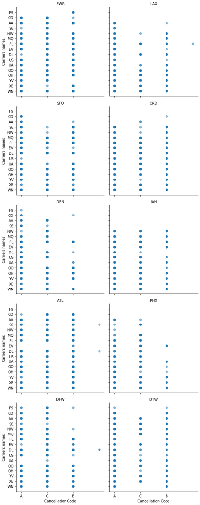

```python
# plot 3 variables : carrier (Carrier, departure delay and Origin

# I use faceting by Origin
Flight_Cancel_plot = sb.FacetGrid(Flights_Top_Arr_Can, col = 'Origin', col_wrap = 2,palette="Set1", size = 4)

# Each graph is a categorical for departure delays and carrier name
Flight_Cancel_plot.map(plt.scatter, 'CancellationCode', 'UniqueCarrier', alpha = .5 )

# set the axis labels
Flight_Cancel_plot.set_axis_labels("Cancellation Code", "Carriers names");

# set each facet title with the Origin name
Flight_Cancel_plot.set_titles("{col_name}");
```

### Talk about some of the relationships you observed in this part of the investigation. Were there features that strengthened each other in terms of looking at your feature(s) of interest?

> ORD Airlines is the most delayed airlaines specially in UA, NW and CO and the delay take more time SFO is best Airlines with less time in the delay.

```python
#save the dataframe to CSV file

flights.to_csv("Flights.csv", index=False)
```

## Refrances

- https://pandas.pydata.org/pandas-docs/stable/user_guide/merging.html
- https://datatofish.com/correlation-matrix-pandas/
- https://stackoverflow.com/questions/21702342/creating-a-new-column-based-on-if-elif-else-condition
- https://stackoverflow.com/questions/39988589/how-to-pass-through-a-list-of-queries-to-a-pandas-dataframe-and-output-the-list
- https://seaborn.pydata.org/generated/seaborn.FacetGrid.html